# Analysis of Weather Events Exploring Most Detrimental Events On Human Population’s Health and Economic Impact

# Synopsis

The NOAA Storm Events Database is processed to provide for meaningful features. Mostly processing involves checking missing values and filtering out where applicable. Then creating meaningful multipliers to get the actual number of economic or health impact respectively. Evaluating the top 10 events per category being total health and total economic damage. Note that the top 10 events includes states but is not top 10 per state, as this would create a very large uninterpretable plot. In addition health category will include a plot for deaths by EVTYPE and STATE, as a death is very absolute whereas injuries is very broad - usually a death should be considered more pertinent than an injury.

# Processing

```r
# Determining Empty or NA Values
colSums(is.na(df))
```

```
##   BGN_DATE     EVTYPE FATALITIES   INJURIES      STATE    PROPDMG PROPDMGEXP
##          0          0          0          0          0          0          0
##    CROPDMG CROPDMGEXP
##          0          0
```

```r
sapply(df, function(col) sum(col == "", na.rm = TRUE))
```

```
##   BGN_DATE     EVTYPE FATALITIES   INJURIES      STATE    PROPDMG PROPDMGEXP
##          0          0          0          0          0          0     465934
##    CROPDMG CROPDMGEXP
##          0     618413
```

```r
# Check where dmg is greater than 0 but multiplier is missing, should be a red flag here
sum(df$PROPDMG > 0 & df$PROPDMGEXP == "")
```

```
## [1] 76
```

```r
# Similarly with cropdmg
sum(df$CROPDMG > 0 & df$CROPDMGEXP == "")
```

```
## [1] 3
```

```r
# Filter out these rows
df <- df[!(df$PROPDMG > 0 & df$PROPDMGEXP == ""), ]
df <- df[!(df$CROPDMG > 0 & df$CROPDMGEXP == ""), ]
```

```r
# Change date column to datetime
df$BGN_DATE <- as.Date(df$BGN_DATE, format = "%m/%d/%Y")
```

```r
# Feature Engineering
# Total Injuries and Fatalities
df$total_health_impact <- df$INJURIES + df$FATALITIES
# Total for property and crop damage
# First Need to Map These Exponents: Looking at unique values we see:
unique(df$CROPDMGEXP)
```

```
## [1] ""  "M" "K" "m" "B" "0" "k" "?" "2"
```

```r
unique(df$PROPDMGEXP)
```

```
##  [1] "K" "M" ""  "B" "m" "+" "0" "5" "6" "?" "4" "2" "3" "h" "7" "H" "-" "1" "8"
```

```r
# Make mapping
exp_map <- c(
  'H' = 1e2, 'K' = 1e3, 'M' = 1e6, 'B' = 1e9,
  'h' = 1e2, 'k' = 1e3, 'm' = 1e6, 'b' = 1e9,
  '0' = 1, '1' = 10, '2' = 100, '3' = 1000,
  '4' = 10000, '5' = 1e5, '6' = 1e6, '7' = 1e7,
  '8' = 1e8, '+' = 1, '-' = 1, '?' = 1
)

df$prop_multiplier <- exp_map[as.character(df$PROPDMGEXP)]
df$crop_multiplier <- exp_map[as.character(df$CROPDMGEXP)]
# Make NAs zero as these were events that didnt cause dmg or have economic impact
df$prop_multiplier[is.na(df$prop_multiplier)] <- 0
df$crop_multiplier[is.na(df$crop_multiplier)] <- 0
# Also add actual values for crop and prop dmg
df$actual_property_damage <- df$PROPDMG * df$prop_multiplier
df$actual_crop_damage     <- df$CROPDMG * df$crop_multiplier
```

```r
# Actually Empty Going to Make total economic based on Either both 0 evaluates to 0 otherwise multiplier * dmg
df_empty_exp <- df[
  (df$PROPDMG > 0 & df$PROPDMGEXP == "") |
  (df$CROPDMG > 0 & df$CROPDMGEXP == ""),
]

# Create total_econ_impact safely
df$total_econ_impact <- ifelse(
  df$PROPDMG == 0 & df$CROPDMG == 0,
  0,
  (df$PROPDMG * df$prop_multiplier) + (df$CROPDMG * df$crop_multiplier)
)
```

# Exploring Health Impact - Deaths and Injuries

```r
library(dplyr)
# Creating Summary Table Should be a lot less observations because of grouping
# Note n_events denoting the count of given event, may look at given summary per
# event to get an idea of severity on avg of an event
event_summary <- df %>%
  group_by(EVTYPE) %>%
  summarise(
    total_fatalities   = sum(FATALITIES, na.rm = TRUE),
    total_injuries     = sum(INJURIES, na.rm = TRUE),
    total_health_impact = sum(FATALITIES + INJURIES, na.rm = TRUE),

    total_prop_damage  = sum(actual_property_damage, na.rm = TRUE),
    total_crop_damage  = sum(actual_crop_damage, na.rm = TRUE),
    total_econ_impact  = sum(total_econ_impact, na.rm = TRUE),

    n_events           = n()
  ) %>%
  arrange(desc(total_health_impact))  # Just the one of many sorts might do
```

```r
str(event_summary)
```

```
## tibble [984 × 8] (S3: tbl_df/tbl/data.frame)
##  $ EVTYPE             : chr [1:984] "TORNADO" "EXCESSIVE HEAT" "TSTM WIND" "FLOOD" ...
##  $ total_fatalities   : num [1:984] 5633 1903 504 470 816 ...
##  $ total_injuries     : num [1:984] 91346 6525 6957 6789 5228 ...
##  $ total_health_impact: num [1:984] 96979 8428 7461 7259 6044 ...
##  $ total_prop_damage  : num [1:984] 5.69e+10 7.75e+06 4.48e+09 1.45e+11 9.30e+08 ...
##  $ total_crop_damage  : num [1:984] 4.15e+08 4.92e+08 5.54e+08 5.66e+09 1.21e+07 ...
##  $ total_econ_impact  : num [1:984] 5.74e+10 5.00e+08 5.04e+09 1.50e+11 9.42e+08 ...
##  $ n_events           : int [1:984] 60651 1678 219940 25324 15753 767 54257 2006 82562 11433 ...
```

```r
# Going to Get a Per Event Average
event_summary <- event_summary %>%
  mutate(
    econ_per_event = total_econ_impact / n_events,
    health_per_event = total_health_impact / n_events
  )
```

```r
# Get summary but by state also
event_summary_state <- df %>%
  group_by(EVTYPE, STATE) %>%
  summarise(
    total_fatalities   = sum(FATALITIES, na.rm = TRUE),
    total_injuries     = sum(INJURIES, na.rm = TRUE),
    total_health_impact = sum(FATALITIES + INJURIES, na.rm = TRUE),

    total_prop_damage  = sum(actual_property_damage, na.rm = TRUE),
    total_crop_damage  = sum(actual_crop_damage, na.rm = TRUE),
    total_econ_impact  = sum(total_econ_impact, na.rm = TRUE),

    n_events           = n(),
    .groups = "drop"
  ) %>%
  arrange(desc(total_health_impact))  # Just the one of many sorts might do

event_summary_state <- event_summary_state %>%
  mutate(
    econ_per_event = total_econ_impact / n_events,
    health_per_event = total_health_impact / n_events
  )
```

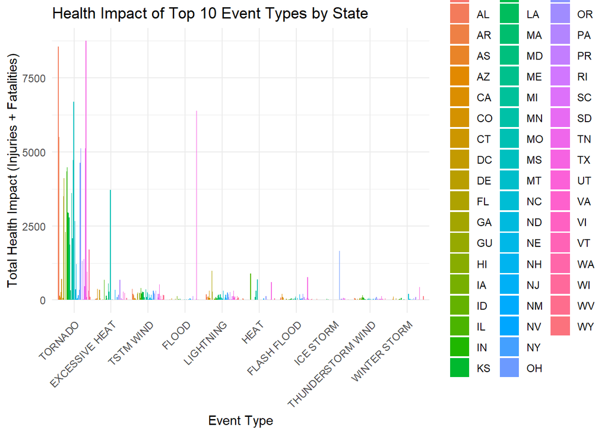

```r
top10_events <- event_summary_state %>%
  group_by(EVTYPE) %>%
  summarise(total_health_impact = sum(total_health_impact, na.rm = TRUE)) %>%
  arrange(desc(total_health_impact)) %>%
  slice_head(n = 10)

filtered_data <- event_summary_state %>%
  filter(EVTYPE %in% top10_events$EVTYPE)

library(ggplot2)

# This looks a bit too cluttered
ggplot(filtered_data, aes(x = reorder(EVTYPE, -total_health_impact),
                          y = total_health_impact, fill = STATE)) +
  geom_col(position = "dodge") +
  labs(title = "Health Impact of Top 10 Event Types by State",
       x = "Event Type", y = "Total Health Impact (Injuries + Fatalities)") +
  theme_minimal() +
  theme(axis.text.x = element_text(angle = 45, hjust = 1))
```

```r
# PLEASE DO IGNORE THIS PLOT IN FIG COUNT IT IS NOT USED IN RESULTS JUST FOR INTUITION!
```

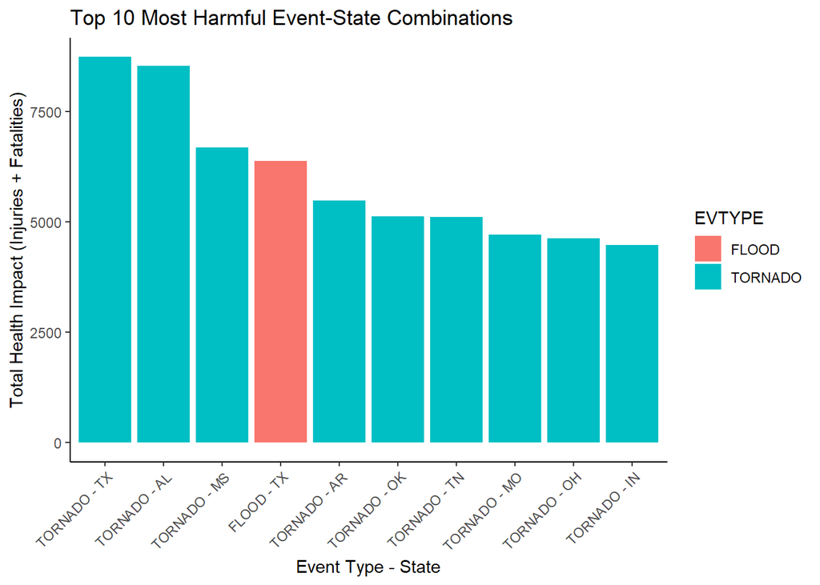

```r
top10_event_state <- event_summary_state %>%
  arrange(desc(total_health_impact)) %>%
  slice_head(n = 10)


health_plot <- ggplot(top10_event_state, aes(x = reorder(paste(EVTYPE, STATE, sep = " - "),
                                          -total_health_impact),
                              y = total_health_impact, fill = EVTYPE)) +
  geom_col() +
  labs(title = "Top 10 Most Harmful Event-State Combinations",
       x = "Event Type - State", y = "Total Health Impact (Injuries + Fatalities)") +
  theme_classic() +
  theme(axis.text.x = element_text(angle = 45, hjust = 1))

print(health_plot)
```

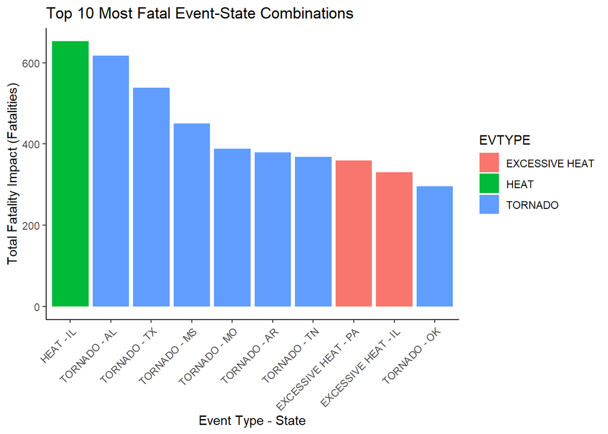

```r
top10_event_state_deaths <- event_summary_state %>%
  arrange(desc(total_fatalities)) %>%
  slice_head(n = 10)


health_plot_deaths <- ggplot(top10_event_state_deaths, aes(x = reorder(paste(EVTYPE, STATE, sep = " - "),
                                          -total_fatalities),
                              y = total_fatalities, fill = EVTYPE)) +
  geom_col() +
  labs(title = "Top 10 Most Fatal Event-State Combinations",
       x = "Event Type - State", y = "Total Fatality Impact (Fatalities)") +
  theme_classic() +
  theme(axis.text.x = element_text(angle = 45, hjust = 1))

print(health_plot_deaths)
```

# Exploring Econ Impact - Property damage and Crop damage

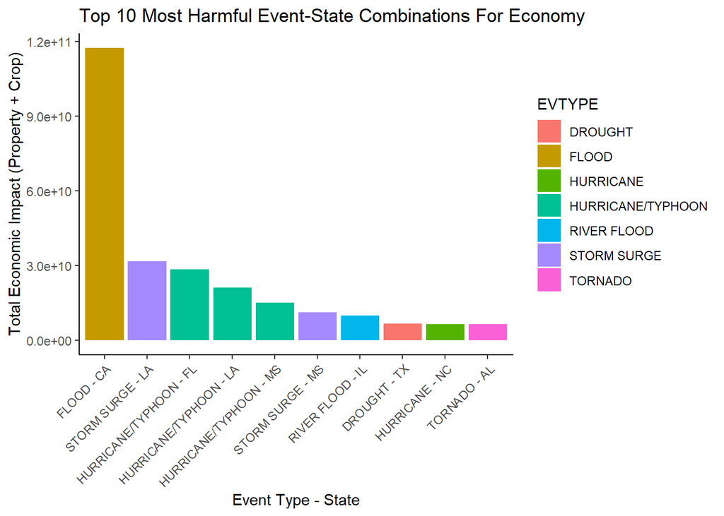

```r
# Note in will have to rewrap results chunk with caption too
# Similarly doing this for total_econ_impact
top10_event_state_econ <- event_summary_state %>%
  arrange(desc(total_econ_impact)) %>%
  slice_head(n = 10)

econ_plot <- ggplot(top10_event_state_econ, aes(x = reorder(paste(EVTYPE, STATE, sep = " - "),
                                               -total_econ_impact),
                                   y = total_econ_impact,
                                   fill = EVTYPE)) +
  geom_col() +
  labs(title = "Top 10 Most Harmful Event-State Combinations For Economy",
       x = "Event Type - State", y = "Total Economic Impact (Property + Crop)",) +
  theme_classic() +
  theme(axis.text.x = element_text(angle = 45, hjust = 1))

print(econ_plot)
```

# Results

## Introduction

The weather events can cause two distinct types of damage that of property and crops which falls under economic impact and the other category is human health which relates to deaths and injuries. This fundamentally seems like it may cause a conflict of interest with policy makers as the main incentives to be re-elected could be from measures of economic growth, whereas human life should be viewed as the most important thing to uphold from an ethical viewpoint.